# Women's E-commerce Clothing Review

```python
import pandas as pd
import numpy as np

import matplotlib.pyplot as plt
import seaborn as sns


sns.set_palette([
    "#30a2da",
    "#fc4f30",
    "#e5ae38",
    "#6d904f",
    "#8b8b8b",
])


import scipy.stats as ss
from statsmodels.formula.api import ols


import re
import nltk
from nltk.stem import WordNetLemmatizer
from nltk.tag import pos_tag

from nltk.sentiment.vader import SentimentIntensityAnalyzer


import string


%matplotlib inline
```

```python
nltk.download('vader_lexicon')
```

```
True
```

```python
import matplotlib
print('matplotlib: {}'.format(matplotlib.__version__))
```

```
matplotlib: 3.2.0
```

```python
df = pd.read_csv("Womens Clothing E-Commerce Reviews.csv")
```

```python
df.head()
```

|  | Unnamed: 0 | Clothing ID | Age | Title | Review Text | Rating | Recommended IND | Positive Feedback Count | Division Name | Department Name | Class Name |
| --- | --- | --- | --- | --- | --- | --- | --- | --- | --- | --- | --- |
| 0 | 0 | 767 | 33 | NaN | Absolutely wonderful - silky and sexy and comf... | 4 | 1 | 0 | Initmates | Intimate | Intimates |
| 1 | 1 | 1080 | 34 | NaN | Love this dress! it's sooo pretty. i happene... | 5 | 1 | 4 | General | Dresses | Dresses |
| 2 | 2 | 1077 | 60 | Some major design flaws | I had such high hopes for this dress and reall... | 3 | 0 | 0 | General | Dresses | Dresses |
| 3 | 3 | 1049 | 50 | My favorite buy! | I love, love, love this jumpsuit. it's fun, fl... | 5 | 1 | 0 | General Petite | Bottoms | Pants |
| 4 | 4 | 847 | 47 | Flattering shirt | This shirt is very flattering to all due to th... | 5 | 1 | 6 | General | Tops | Blouses |

```python
df.info()
```

```
<class 'pandas.core.frame.DataFrame'>
RangeIndex: 23486 entries, 0 to 23485
Data columns (total 11 columns):
Unnamed: 0                 23486 non-null int64
Clothing ID                23486 non-null int64
Age                        23486 non-null int64
Title                      19676 non-null object
Review Text                22641 non-null object
Rating                     23486 non-null int64
Recommended IND            23486 non-null int64
Positive Feedback Count    23486 non-null int64
Division Name              23472 non-null object
Department Name            23472 non-null object
Class Name                 23472 non-null object
dtypes: int64(6), object(5)
memory usage: 2.0+ MB
```

```python
df.isnull().sum()
```

```
Unnamed: 0                    0
Clothing ID                   0
Age                           0
Title                      3810
Review Text                 845
Rating                        0
Recommended IND               0
Positive Feedback Count       0
Division Name                14
Department Name              14
Class Name                   14
dtype: int64
```

```python
df.isnull().sum()/len(df)*100
```

```
Unnamed: 0                  0.000000
Clothing ID                 0.000000
Age                         0.000000
Title                      16.222430
Review Text                 3.597888
Rating                      0.000000
Recommended IND             0.000000
Positive Feedback Count     0.000000
Division Name               0.059610
Department Name             0.059610
Class Name                  0.059610
dtype: float64
```

```python
df[df['Review Text'].isnull()]['Title'].value_counts()
```

```
Such a beautiful dress!    1
Name: Title, dtype: int64
```

```python
dft = df.copy()
```

```python
for col in ['Review Text', 'Division Name', 'Department Name', 'Class Name']:
    dft = dft[dft[col].notnull()]
```

```python
len(dft)/len(df)
```

```
0.9634675977177893
```

```python
dft.drop(columns= 'Unnamed: 0', inplace = True)
```

```python
dft.head()
```

|  | Clothing ID | Age | Title | Review Text | Rating | Recommended IND | Positive Feedback Count | Division Name | Department Name | Class Name |
| --- | --- | --- | --- | --- | --- | --- | --- | --- | --- | --- |
| 0 | 767 | 33 | NaN | Absolutely wonderful - silky and sexy and comf... | 4 | 1 | 0 | Initmates | Intimate | Intimates |
| 1 | 1080 | 34 | NaN | Love this dress! it's sooo pretty. i happene... | 5 | 1 | 4 | General | Dresses | Dresses |
| 2 | 1077 | 60 | Some major design flaws | I had such high hopes for this dress and reall... | 3 | 0 | 0 | General | Dresses | Dresses |
| 3 | 1049 | 50 | My favorite buy! | I love, love, love this jumpsuit. it's fun, fl... | 5 | 1 | 0 | General Petite | Bottoms | Pants |
| 4 | 847 | 47 | Flattering shirt | This shirt is very flattering to all due to th... | 5 | 1 | 6 | General | Tops | Blouses |

## EDA

### Clothing ID Distribution

Popularity of products

```python
#dft[dft["Clothing ID"].isin(
#dft[dft['Clothing ID'].isin(dft["Clothing ID"].value_counts()[:60].index)]
```

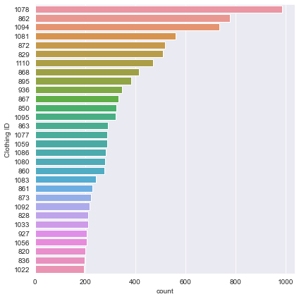

```python
#z =dft['Clothing ID'].value_counts()
plt.figure(figsize=(6,6))
sns.countplot(y='Clothing ID', data= dft[dft["Clothing ID"].isin(dft["Clothing ID"].value_counts()[:30].index)],
             order = dft["Clothing ID"].value_counts()[:30].index);
plt.tight_layout()
```

```python
dft[dft['Clothing ID'].isin([1078, 862, 1094, 1081])][["Title", "Division Name","Department Name","Class Name"]]\
.describe().T.drop('count', axis=1)
```

|  | unique | top | freq |
| --- | --- | --- | --- |
| Title | 2171 | Beautiful dress | 24 |
| Division Name | 2 | General | 1708 |
| Department Name | 2 | Dresses | 2283 |
| Class Name | 2 | Dresses | 2283 |

### Other Univariate Distributions

```python
def displot(data, title, num=1,bins=[30]):
    sns.set_style('whitegrid')
    f, ax = plt.subplots(1,num, figsize=(10,5))

    if num==1:

        sns.distplot(data, bins=bins[0])
    else:
        for i,d in enumerate(data):
            sns.distplot(d, bins=bins[i], ax=ax[i])
    plt.title(title)
    plt.ylabel('Density')
```

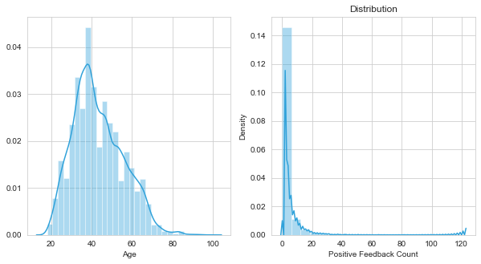

```python
displot([dft['Age'], dft['Positive Feedback Count']], 'Distribution', num=2, bins=[30,20])
```

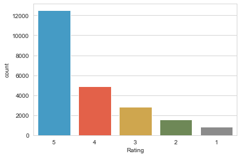

```python
sns.countplot(dft['Rating'],order=range(5,0,-1));
```

```python
def cplot(data, num=1, size=7):
    sns.set_style('whitegrid')
    f, ax = plt.subplots(1,num, figsize=(size*num,6))

    if num==1:

        sns.countplot(data, order=data.value_counts().sort_values(ascending=False).index, palette='viridis')
    else:
        for i,d in enumerate(data):
            sns.countplot(d, order=d.value_counts().sort_values(ascending=False).index, palette='viridis', ax=ax[i])
    plt.tight_layout()
```

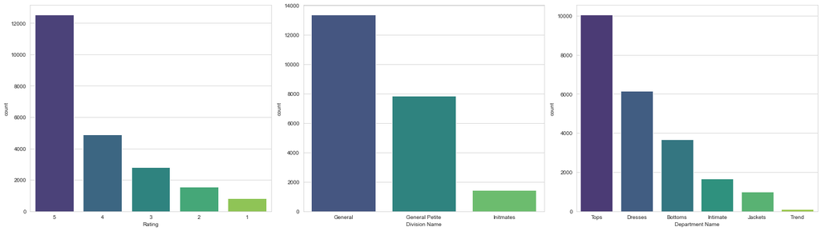

```python
cplot([dft['Rating'], dft['Division Name'], dft['Department Name']], num=3)
```

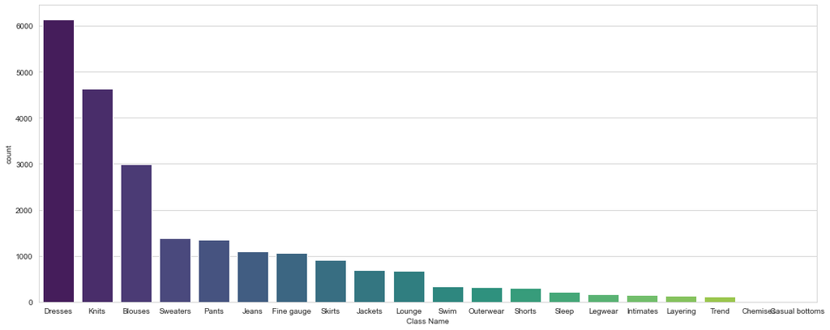

```python
cplot(dft['Class Name'], size=15)
```

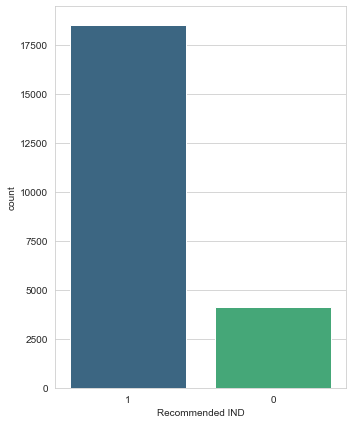

```python
cplot(dft['Recommended IND'], size=5)
```

Skewed classes

### Multivariate Analysis

#### Categorical vs Categorical Variables

```python
dft.dtypes
```

```
Clothing ID                 int64
Age                         int64
Title                      object
Review Text                object
Rating                      int64
Recommended IND             int64
Positive Feedback Count     int64
Division Name              object
Department Name            object
Class Name                 object
dtype: object
```

```python
def highlight_max(s):
    '''
    highlight the maximum in a Series.
    '''
    is_max = s == s.max()
    return ['background-color: darkorange' if v else '' for v in is_max]
cm = pd.crosstab(dft['Division Name'], dft['Department Name'], normalize='index').mul(100).round(0)
cm.style.apply(highlight_max, axis=1)
```

| Department Name Division Name | Bottoms | Dresses | Intimate | Jackets | Tops | Trend |
| --- | --- | --- | --- | --- | --- | --- |
| General | 18 | 27 | 0 | 5 | 49 | 1 |
| General Petite | 16 | 32 | 3 | 5 | 44 | 0 |
| Initmates | 0 | 0 | 100 | 0 | 0 | 0 |

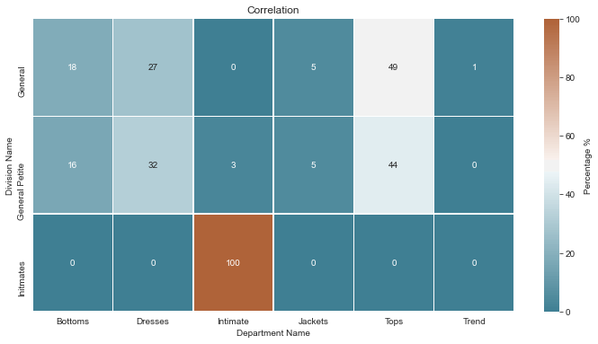

```python
plt.subplots(figsize=(12,6))
sns.heatmap(pd.crosstab(dft['Division Name'], dft['Department Name'],normalize='index').mul(100).round(0),\
            annot=True, linewidth=0.5,\
            cmap=sns.diverging_palette(220, 30, n=200),fmt='g',\
            cbar_kws={'label': 'Percentage %'});
plt.title('Correlation')
```

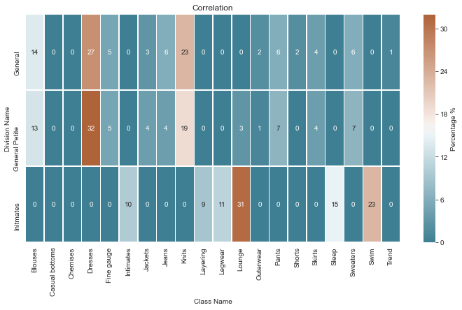

```python
plt.subplots(figsize=(12,6))
sns.heatmap(pd.crosstab(dft['Division Name'], dft['Class Name'],normalize='index').mul(100).round(0),\
            annot=True, linewidth=0.5,\
            cmap=sns.diverging_palette(220, 30, n=200),fmt='g',\
            cbar_kws={'label': 'Percentage %'});
plt.title('Correlation')
```

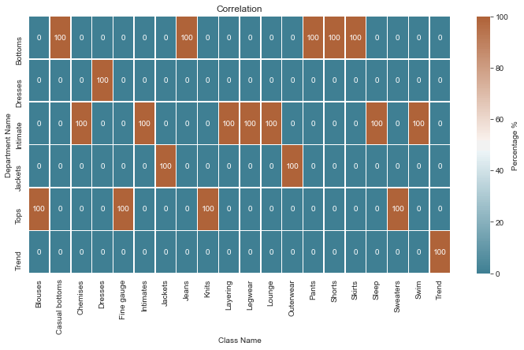

```python
plt.subplots(figsize=(12,6))
sns.heatmap(pd.crosstab(dft['Department Name'], dft['Class Name'],normalize='columns').mul(100).round(0),\
            annot=True, linewidth=0.5,\
            cmap=sns.diverging_palette(220, 30, n=200),fmt='g',\
            cbar_kws={'label': 'Percentage %'});
plt.title('Correlation')
```

```python
dft[['Division Name', 'Department Name', 'Class Name']].apply(lambda x : pd.factorize(x)[0])+1
```

|  | Division Name | Department Name | Class Name |
| --- | --- | --- | --- |
| 0 | 1 | 1 | 1 |
| 1 | 2 | 2 | 2 |
| 2 | 2 | 2 | 2 |
| 3 | 3 | 3 | 3 |
| 4 | 2 | 4 | 4 |
| ... | ... | ... | ... |
| 23481 | 3 | 2 | 2 |
| 23482 | 3 | 4 | 5 |
| 23483 | 3 | 2 | 2 |
| 23484 | 2 | 2 | 2 |
| 23485 | 3 | 2 | 2 |

22628 rows × 3 columns

```python
from scipy.stats import chisquare

dd = dft[['Division Name', 'Department Name', 'Class Name']].apply(lambda x : pd.factorize(x)[0])+1

pd.DataFrame([chisquare(dd[x].values,f_exp=dd.values.T,axis=1)[0] for x in dd])
```

|  | 0 | 1 | 2 |
| --- | --- | --- | --- |
| 0 | 0.000000 | 12147.100000 | 62501.192072 |
| 1 | 20825.166667 | 0.000000 | 42030.749534 |
| 2 | 399578.333333 | 275349.033333 | 0.000000 |

```python
def cramers_v(confusion_matrix):
    """ calculate Cramers V statistic for categorial-categorial association.
        uses correction from Bergsma and Wicher,
        Journal of the Korean Statistical Society 42 (2013): 323-328
    """
    chi2, p, dof, _  = ss.chi2_contingency(confusion_matrix)
    n = confusion_matrix.sum()
    phi2 = chi2 / n
    r, k = confusion_matrix.shape
    phi2corr = max(0, phi2 - ((k-1)*(r-1))/(n-1))
    rcorr = r - ((r-1)**2)/(n-1)
    kcorr = k - ((k-1)**2)/(n-1)
    return (np.sqrt(phi2corr / min((kcorr-1), (rcorr-1))), p, dof)
```

```python
cat_col = ["Division Name", "Department Name", "Class Name"]
```

```python
# ct = pd.crosstab(dft['Division Name'], dft['Class Name'], normalize='index').mul(100).round(0)
# cramers_v(ct.values+0.1)
```

```python
V = []
for cat1 in cat_col:
    for cat2 in cat_col:
        ct = pd.crosstab(dft[cat1], dft[cat2], normalize='index').mul(100).round(0)
        if cat1 == 'Class Name' or (cat2== 'Class Name'):
            v, _, _ = cramers_v(ct.values+0.1) ## since empty rows and columns result in error (division by 0)
        else:
            v, _, _ = cramers_v(ct.values)
        V.append(v)
```

```python
cat_df = pd.DataFrame(data =np.array(V).reshape(3,3), index=cat_col, columns=cat_col)
```

```python
cat_df.style.apply(highlight_max, axis=1)
```

|  | Division Name | Department Name | Class Name |
| --- | --- | --- | --- |
| Division Name | 1 | 0.685066 | 0.642323 |
| Department Name | 0.654187 | 1 | 0.969538 |
| Class Name | 0.719389 | 0.987969 | 0.980206 |

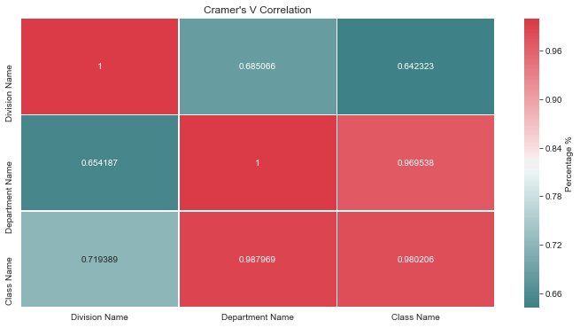

```python
plt.subplots(figsize=(12,6))
sns.heatmap(cat_df,\
            annot=True, linewidth=0.5,\
            cmap=sns.diverging_palette(200, 10, n=200),fmt='g',\
            cbar_kws={'label': 'Percentage %'});
plt.title("Cramer's V Correlation");
```

#### Numerical vs Numerical Variables

```python
num_col = dft.select_dtypes(include=['int64']).columns
num_col
```

```
Index(['Clothing ID', 'Age', 'Rating', 'Recommended IND',
       'Positive Feedback Count'],
      dtype='object')
```

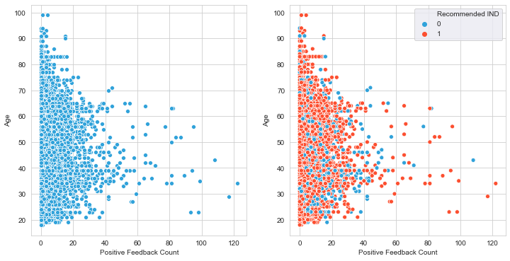

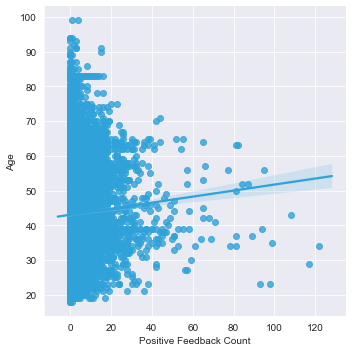

```python
f, ax = plt.subplots(1,2, figsize=(12,6))
sns.set_style('darkgrid')
sns.scatterplot(x=dft['Positive Feedback Count'], y=dft['Age'], ax=ax[0]);
sns.scatterplot(x=dft['Positive Feedback Count'], y=dft['Age'], hue=dft['Recommended IND'], ax=ax[1]);
lm = sns.lmplot(data=dft, x='Positive Feedback Count', y='Age', fit_reg=True);
```

```python
dft[['Positive Feedback Count' , 'Age']].corr(method='pearson')
```

|  | Positive Feedback Count | Age |
| --- | --- | --- |
| Positive Feedback Count | 1.000000 | 0.040807 |
| Age | 0.040807 | 1.000000 |

```python
ss.pearsonr(dft['Positive Feedback Count'], dft['Age'])
```

```
(0.040807031516878665, 8.217953916448058e-10)
```

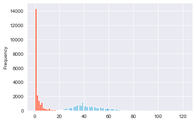

```python
dft['Age'].plot(kind='hist', bins=100)
dft['Positive Feedback Count'].plot(kind='hist', bins=100);
```

Not much correlation between the attributes as seen by pearson correlation coefficient. Also distribution of 'positive feedback count' is not normal.

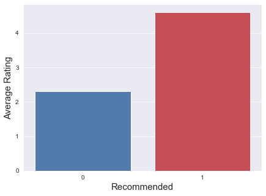

```python
f, ax = plt.subplots(figsize=(7,5))
b = sns.barplot(y = 'Rating',x= [0,1], \
            data =dft[['Rating', 'Recommended IND']].groupby('Recommended IND').mean(),\
           palette=sns.diverging_palette(250, 10, n=2));
b.set_xlabel('Recommended', size=15)
b.set_ylabel('Average Rating', size=15);
```

Average Recommended item rating is around 5 and non recommeded ones around 2. As expected.

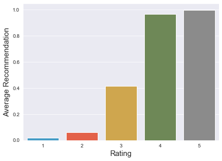

```python
f, ax = plt.subplots(figsize=(7,5))
b = sns.barplot(y = 'Recommended IND',x= [1,2,3,4,5], \
            data =dft[['Rating', 'Recommended IND']].groupby('Rating').mean(),\
           );
b.set_xlabel('Rating', size=15)
b.set_ylabel('Average Recommendation', size=15);
```

Items with rating below 3 are not recommended which makes sense

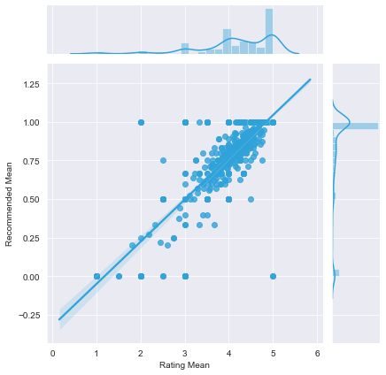

```python
temp = (dft.groupby('Clothing ID')[["Rating","Recommended IND", "Age"]]
        .aggregate(['count','mean']))
temp.columns = ["Count","Rating Mean","Recommended IND Count",
                 "Recommended Mean","Age Count","Age Mean"]
temp.drop(["Recommended IND Count","Age Count"], axis=1, inplace =True)
sns.jointplot(x='Rating Mean', y='Recommended Mean', data=temp, kind='reg')
```

```python
ss.pearsonr(temp['Rating Mean'], temp['Recommended Mean'])
```

```
(0.7961478196812519, 1.6074854843209124e-257)
```

Strong correlation between Ratings and Recommendations as expected, items that receive good ratings are often recommended. THis is backed by Pearson coefficent with P value almost 0.

Couple of items however have received good ratings but with no recommendations in the chart above. Lets look at those

```python
temp[(temp['Rating Mean'] ==5 )& (temp['Recommended Mean'] == 0)]
```

| Clothing ID | Count | Rating Mean | Recommended Mean | Age Mean |
| --- | --- | --- | --- | --- |
| 53 | 1 | 5.0 | 0.0 | 29.0 |
| 776 | 1 | 5.0 | 0.0 | 56.0 |

```python
dft[dft['Clothing ID'].isin([776,53])]
```

|  | Clothing ID | Age | Title | Review Text | Rating | Recommended IND | Positive Feedback Count | Division Name | Department Name | Class Name |
| --- | --- | --- | --- | --- | --- | --- | --- | --- | --- | --- |
| 12032 | 776 | 56 | Really comfy socks | Yes,you need these, so comfortable - and wash ... | 5 | 0 | 0 | Initmates | Intimate | Legwear |
| 17968 | 53 | 29 | NaN | Very cute shorts. sadly, after one wash they b... | 5 | 0 | 0 | General | Bottoms | Shorts |

```python
temp.rename(mapper={'Rating Mean':'Rating_Mean', 'Recommended Mean': 'Recommended_Mean', 'Age Mean': 'Age_Mean'},
             axis=1,inplace=True)
temp
```

| Clothing ID | Count | Rating_Mean | Recommended_Mean | Age_Mean |
| --- | --- | --- | --- | --- |
| 1 | 3 | 4.000000 | 0.666667 | 36.666667 |
| 2 | 1 | 4.000000 | 1.000000 | 28.000000 |
| 3 | 1 | 5.000000 | 1.000000 | 36.000000 |
| 4 | 1 | 5.000000 | 1.000000 | 28.000000 |
| 5 | 1 | 5.000000 | 1.000000 | 39.000000 |
| ... | ... | ... | ... | ... |
| 1200 | 1 | 3.000000 | 0.000000 | 24.000000 |
| 1202 | 9 | 4.333333 | 1.000000 | 42.000000 |
| 1203 | 7 | 4.428571 | 0.714286 | 39.142857 |
| 1204 | 2 | 4.500000 | 1.000000 | 39.000000 |
| 1205 | 2 | 5.000000 | 1.000000 | 51.500000 |

1172 rows × 4 columns

```python
results = ols('Recommended_Mean ~ Rating_Mean', data=temp).fit()
results.summary()
```

OLS Regression Results

| Dep. Variable: | Recommended_Mean | R-squared: | 0.634 |
| --- | --- | --- | --- |
| Model: | OLS | Adj. R-squared: | 0.634 |
| Method: | Least Squares | F-statistic: | 2025. |
| Date: | Mon, 13 Apr 2020 | Prob (F-statistic): | 1.61e-257 |
| Time: | 19:19:03 | Log-Likelihood: | 364.09 |
| No. Observations: | 1172 | AIC: | -724.2 |
| Df Residuals: | 1170 | BIC: | -714.0 |
| Df Model: | 1 |  |  |
| Covariance Type: | nonrobust |  |  |

|  | coef | std err | t | P>\|t\| | [0.025 | 0.975] |
| --- | --- | --- | --- | --- | --- | --- |
| Intercept | -0.3235 | 0.026 | -12.464 | 0.000 | -0.374 | -0.273 |
| Rating_Mean | 0.2736 | 0.006 | 45.005 | 0.000 | 0.262 | 0.286 |

| Omnibus: | 154.960 | Durbin-Watson: | 1.986 |
| --- | --- | --- | --- |
| Prob(Omnibus): | 0.000 | Jarque-Bera (JB): | 1020.244 |
| Skew: | -0.401 | Prob(JB): | 2.86e-222 |
| Kurtosis: | 7.500 | Cond. No. | 22.5 |

Warnings:  
[1] Standard Errors assume that the covariance matrix of the errors is correctly specified.

Even if we have good r2 value with statisitical significance (low P), we need to check if the regression meets the assumption. The bottom table shows some metrics that can be used to check if it meets the assumption.

##### Omnibus:

It's basically ANOVA, it tests the data as a whole. We can test the homegenity of Variance. P-value is quite signifcant at 0.

##### Skew and Kurtosis:

Normal distribution has a skew of zero and kurtosis of 3. The rule of thumb seems to be:

- If the skewness is between -0.5 and 0.5, the data are fairly symmetrical.
- If the skewness is between -1 and -0.5(negatively skewed) or between 0.5 and 1(positively skewed), the data are moderately skewed.
- If the skewness is less than -1(negatively skewed) or greater than 1(positively skewed), the data are highly skewed.

Kurtosis shows the outliers, data set is an indicator that data has heavy tails or outliers.

#### Durban-Watson:

Measure of autocorrelation usually for time series.

#### Jarque-Bera:

Test for normality. In general, a large J-B value indicates that errors are not normally distributed.

#### Cond. No:

A test for multicollinearity (if in a fit with multiple parameters, the parameters are related with each other).

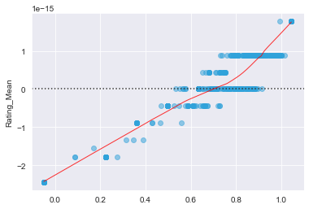

```python
model_fitted_y = results.fittedvalues
model_residuals = results.resid
model_abs_resid = np.abs(model_residuals)

sns.residplot(model_fitted_y, temp['Rating_Mean'], data=temp,
                              lowess=True,
                              scatter_kws={'alpha': 0.5},
                              line_kws={'color': 'red', 'lw': 1, 'alpha': 0.8})
```

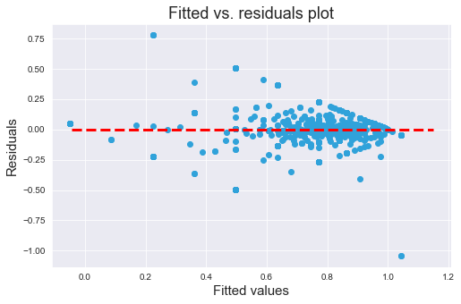

```python
plt.figure(figsize=(8,5))
p = plt.scatter(x=model_fitted_y, y=model_residuals)
xmin=min(model_fitted_y)
xmax = max(model_fitted_y)
plt.hlines(y=0,xmin=xmin*0.9,xmax=xmax*1.1,color='red',linestyle='--',lw=3)
plt.xlabel("Fitted values",fontsize=15)
plt.ylabel("Residuals",fontsize=15)
plt.title("Fitted vs. residuals plot",fontsize=18)
plt.grid(True)
plt.show()
```

We can see the variance of residuals is not uniform across the regression line (the residual = 0 line corresponds to the estimated regression line). Hence relationship isn't linear, the problem does not respect homoscedasticity.

```python
from sklearn.linear_model import LinearRegression

LR = LinearRegression(fit_intercept=True).fit(np.array(temp['Rating_Mean']).reshape(-1,1), temp['Recommended_Mean'])
```

```python
print(LR.coef_)
print(results.params)
```

```
[0.27358224]
Intercept     -0.323460
Rating_Mean    0.273582
dtype: float64
```

#### Numerical vs Categorical Variables

```python
dft.dtypes
```

```
Clothing ID                 int64
Age                         int64
Title                      object
Review Text                object
Rating                      int64
Recommended IND             int64
Positive Feedback Count     int64
Division Name              object
Department Name            object
Class Name                 object
dtype: object
```

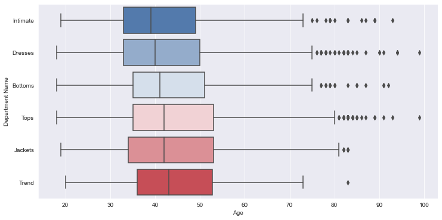

```python
plt.subplots(figsize=(12,6))
sns.set_style('darkgrid')
sns.boxplot(x=dft['Age'], y = dft['Department Name'], palette=sns.diverging_palette(250, 10, n=6));
```

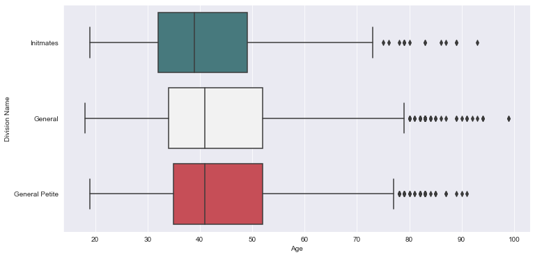

```python
plt.subplots(figsize=(12,6))
sns.set_style('darkgrid')
sns.boxplot(x=dft['Age'], y = dft['Division Name'], palette=sns.diverging_palette(200, 10, n=3));
```

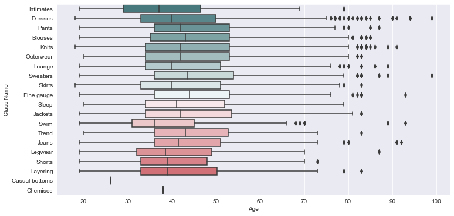

```python
plt.subplots(figsize=(12,6))
sns.set_style('darkgrid')
sns.boxplot(x=dft['Age'], y = dft['Class Name'],palette=sns.diverging_palette(200, 10, n=20));
```

```python
dff = dft[['Age', 'Division Name']]
dff1 = dff[dff['Division Name'] == 'Initmates']['Age']
dff2 = dff[dff['Division Name'] == 'General']['Age']
dff3 = dff[dff['Division Name'] == 'General Petite']['Age']
```

```python
dff.groupby('Division Name').mean()
```

| Division Name | Age |
| --- | --- |
| General | 43.426712 |
| General Petite | 43.400153 |
| Initmates | 41.290323 |

```python
dff1
```

```
0        33
13       44
25       31
28       53
34       39
         ..
23249    34
23318    39
23425    23
23438    68
23476    27
Name: Age, Length: 1426, dtype: int64
```

```python
ss.f_oneway(dff1, dff2, dff3)
```

```
F_onewayResult(statistic=19.923191829766157, pvalue=2.2650514208092683e-09)
```

The F-statistic= 19.923 and the p-value is much < 0.001 which is indicating that there is an overall significant effect of Division Name on Age.

```python
dff = dff.rename(columns={"Division Name": "Division_Name"})
```

```python
results = ols('Age ~ C(Division_Name)', data=dff).fit()
results.summary()
```

OLS Regression Results

| Dep. Variable: | Age | R-squared: | 0.002 |
| --- | --- | --- | --- |
| Model: | OLS | Adj. R-squared: | 0.002 |
| Method: | Least Squares | F-statistic: | 19.92 |
| Date: | Mon, 13 Apr 2020 | Prob (F-statistic): | 2.27e-09 |
| Time: | 19:19:06 | Log-Likelihood: | -88926. |
| No. Observations: | 22628 | AIC: | 1.779e+05 |
| Df Residuals: | 22625 | BIC: | 1.779e+05 |
| Df Model: | 2 |  |  |
| Covariance Type: | nonrobust |  |  |

|  | coef | std err | t | P>\|t\| | [0.025 | 0.975] |
| --- | --- | --- | --- | --- | --- | --- |
| Intercept | 43.4267 | 0.107 | 407.573 | 0.000 | 43.218 | 43.636 |
| C(Division_Name)[T.General Petite] | -0.0266 | 0.175 | -0.152 | 0.880 | -0.370 | 0.317 |
| C(Division_Name)[T.Initmates] | -2.1364 | 0.343 | -6.226 | 0.000 | -2.809 | -1.464 |

| Omnibus: | 916.673 | Durbin-Watson: | 1.990 |
| --- | --- | --- | --- |
| Prob(Omnibus): | 0.000 | Jarque-Bera (JB): | 1027.304 |
| Skew: | 0.519 | Prob(JB): | 8.39e-224 |
| Kurtosis: | 2.881 | Cond. No. | 4.55 |

Warnings:  
[1] Standard Errors assume that the covariance matrix of the errors is correctly specified.

The intercept group is the General category group since the General group’s data was not included in the model’s formula. Their data is still captured because this group has values of 0 in both of the other groups.

Overall the model is significant with F = 19.92 and P much less than 0.01. This tells there is significant difference in group means. The coefficients (coef in the table), are the difference in mean between the control group and the respective group listed.

The bottom of the table there are a few tests that were conducted to test the models’s assumptions.

The Durban-Watson tests is to detect the presence of autocorrelation, Jarque-Bera tests the assumption of normality, Omnibus tests the assumption of homogeneity of variance, and the Condition Number (condno) assess multicollinearity. Condition Number values over 20 are indicative of multicollinearity.

```python
import statsmodels.api as sm
aov_table = sm.stats.anova_lm(results, typ=2)
aov_table
```

|  | sum_sq | df | F | PR(>F) |
| --- | --- | --- | --- | --- |
| C(Division_Name) | 6.045897e+03 | 2.0 | 19.923192 | 2.265051e-09 |
| Residual | 3.432894e+06 | 22625.0 | NaN | NaN |

The Division_Name row is the between groups effect which is the overall experimental effect. The sum of squares for the model is how much variance is explained by our model while the Residual SSM is unexplained variance.

https://pythonfordatascience.org/anova-python/

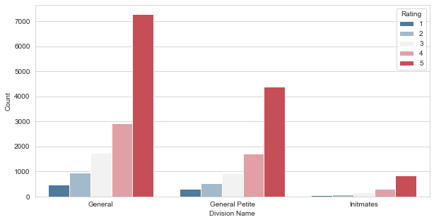

```python
sns.set_style('whitegrid')
plt.subplots(figsize=(10,5))
a = dft[['Division Name', 'Rating']]\
.groupby(['Division Name'])['Rating']\
.value_counts()\
.rename('Count')\
.reset_index()\
.sort_values('Rating')
sns.barplot(x='Division Name', y = 'Count', hue='Rating', data=a, palette=sns.diverging_palette(240, 10, n=5, center="light"));
```

```python
def percentagebarplot(x, y, hue, data, ax=None, n=5):
    sns.barplot(x =x, y =y, hue=hue,\
                data = data[[x, hue]]\
                .reset_index(drop=True)\
                .groupby([x])[hue]\
                .value_counts(normalize=True)\
                .rename('Percentage').mul(100)\
                .reset_index()\
                .sort_values(hue),\
                palette=sns.diverging_palette(240, 10, n=n, center="light"),\
               ax =ax)
```

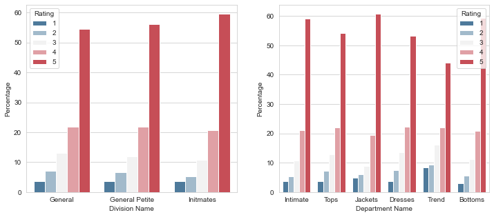

```python
f, ax = plt.subplots(1,2, figsize=(12,5))

percentagebarplot(x='Division Name', y ='Percentage', hue='Rating',  data=dft, ax=ax[0], n=5)
percentagebarplot(x='Department Name', y ='Percentage', hue='Rating',  data=dft, ax=ax[1], n=5)
plt.show()
```

Distribution of ratings standardized by percentage against each Category in Division and Department. Since variables are imbalance counts doens't reflect the true proportions (as seen from previous chart).

```python
a
```

|  | Division Name | Rating | Count |
| --- | --- | --- | --- |
| 4 | General | 1 | 479 |
| 9 | General Petite | 1 | 291 |
| 14 | Initmates | 1 | 51 |
| 3 | General | 2 | 950 |
| 8 | General Petite | 2 | 524 |
| 13 | Initmates | 2 | 75 |
| 2 | General | 3 | 1740 |
| 7 | General Petite | 3 | 929 |
| 12 | Initmates | 3 | 154 |
| 1 | General | 4 | 2910 |
| 6 | General Petite | 4 | 1702 |
| 11 | Initmates | 4 | 296 |
| 0 | General | 5 | 7286 |
| 5 | General Petite | 5 | 4391 |
| 10 | Initmates | 5 | 850 |

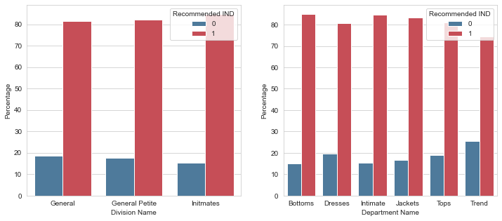

```python
f, ax = plt.subplots(1,2, figsize=(12,5))

percentagebarplot(x='Division Name', y ='Percentage', hue='Recommended IND',  data=dft, ax=ax[0], n=2)
percentagebarplot(x='Department Name', y ='Percentage', hue='Recommended IND',  data=dft, ax=ax[1], n=2)
plt.show()
```

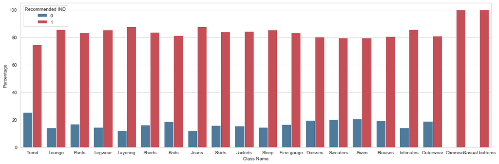

```python
f, ax = plt.subplots(figsize=(15,5))

percentagebarplot(x='Class Name', y ='Percentage', hue='Recommended IND',  data=dft, n=2)
#percentagebarplot(x='Department Name', y ='Percentage', hue='Recommended IND',  data=dft, ax=ax[1], n=2)
plt.tight_layout()
plt.show()
```

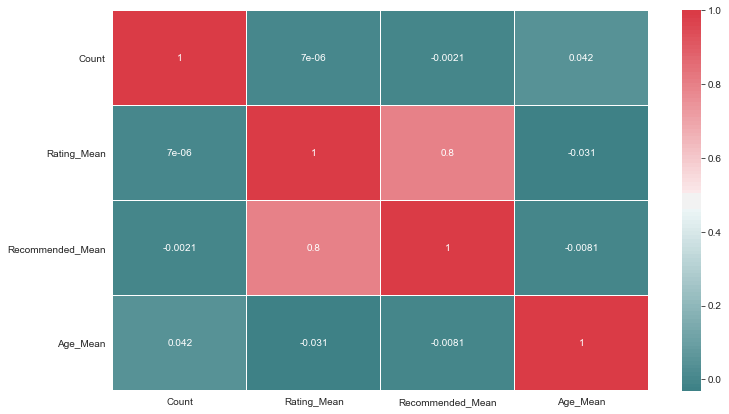

```python
f, ax = plt.subplots(figsize=(12,7))

sns.heatmap(temp.corr(),annot=True, cmap=sns.diverging_palette(200, 10, n=100), linecolor='white',lw=0.1);
```

### Text Analysis

```python
pd.set_option('max_colwidth', 500)
dft[['Title','Review Text', 'Rating']].sample(20)
```

|  | Title | Review Text | Rating |
| --- | --- | --- | --- |
| 9868 | So dang cute | Love this quirky romper. i'm normally a m/l or 10/12 and took a large in this. as the other reviews stated, it's a bit of a contortion act to get into and out of this but when in it fits well, is flat… | 5 |
| 4204 | Beautiful flowy top | This top is even better than pictured. the colors are brighter, though still natural. this allows lots of possibilities with pairing bottoms to it. i ordered a large (my usual size) and would say it's… | 5 |
| 18366 | Great, but... | Loved the dress. loved the pattern and the cut. unfortunately it did not work for me. it is cut too low under the arm pits and therefore, showed too much breast. it is not made to wear a bra with eith… | 4 |
| 21414 | Disappointed | I was so smitten by this shirt when i saw it online. i love embroidery and purple is my favorite color. i am a size 10 and decided to order an l. the shoulders fit well, but the rest of it was huge...… | 2 |
| 12009 | Lovely dress | Wore this dress for my bridal shower and got a ton of compliments! it fits great and is very well made! | 5 |
| 5929 | Love, love, love this top!! | This top is awesome!! it is feminine and flattering at the same time! the color also makes it a little romantic. i will wear it with jeans or very a little dressier night out, black pants. buy this an… | 5 |
| 17252 | Love the turquoise graphic design | I am usually a small sometimes medium. purchased a small and want to wear it off the shoulder but it is too tight and the fabric is scratchy. it is a crepe fabric and although beautiful the hand of th… | 4 |
| 15519 | Exquisite and unique dress | This very unique dress is exquisite and so versatile ? suitable for daytime or evening, and will look great with a cardigan and tights for year-round wear. it fits perfectly and seems true to size to … | 5 |
| 13060 | NaN | Soft, very thin material. perfect for summer but very difficult to wear without a bra because it is so thin it shows quite a bit. the chest is tight but you can adjust the fit by the neck tie. looks e… | 4 |
| 8159 | NaN | Mine was slightly tight across the bust area, but i'm able to leave it open with a light tank underneath. it still looks great! | 5 |
| 7668 | NaN | Saw this in my local and retailer store and had to have it! well made and easy to dress up for down. perfect with a light weight shirt tucked in for summer and early fall. i recommend sizing up one si… | 5 |
| 11246 | Cute jacket | I just received this jacket in the cream color. it is so cute! you can change it from 3/4 to full length sleeves. i ordered both an xs and s and kept the s after i saw that i could cinch the waist to … | 5 |
| 10530 | Had high hopes! | I had sized down because i'm usually a petite, but didn't have the option for petite here, and it was still too big. a petite or an additional size down could have helped the fit, but in the end the s… | 4 |
| 17749 | NaN | So versatile\ni tried this on in my usual regular 0, but it was way too long at the shoulders, large in the bust(i am 32b), and a tad too long overall. i ordered the 0p and it fits perfectly! can wear… | 5 |
| 12064 | Didn't meet my expectations | The dress didn't meet my expectations, specifically the color, the texture, and the cut of the dress. although the dress was very well made, it just wasn't right for me. | 2 |
| 14545 | Great drape! | I love how this long sweater drapes. it's soft -feels great on - and looks fabulous over leggings or skinnys! | 5 |
| 7166 | I like it. (maybe.) | This dress must be pinned on the model in the picture.\ni ordered a small although i really needed a petite small, but it was sold out. it is incredibly billowy. very billowy. i love the print and the… | 4 |
| 1159 | Not sure what body type this suit is designed for | I was so excited to splurge on a mara hoffman suit and was sorely disappointed when i received this suit in the mail. i'm petite and fairly curvy, so i knew it would likely be a little long in the tor… | 1 |
| 12255 | Great maternity dress | I wanted to love this dress. i went into retailer in sb to try it on and when i saw it on the rack it looked beautiful, both the print and the material. then i tried it on and it fit like a tent. i am… | 3 |
| 19670 | Cute shirt | I agree with the other reviewers. this shirt is cuter in person. it is a flattering cut and the design is even prettier than in the photos. the color is more navy--not the charcoal color it looks in t… | 5 |

We can see there are lots of non-word characters that we would like to remove first for basic text analysis. Later we can use these non-words (puntuations, heights etc.) to form features.

```python
def cleanText(text):

    #Remove non-alpha characters
    text = re.sub(r'[^a-zA-Z0-9 ]', '',text)
    #Remove multiple spaces, replace by single space
    text = re.sub(r'  +', ' ', text)
    #Lower case all
    text = text.lower()

    return text
```

```python
t = "Awesome             shirt...great'"''" transition £!*$*(Q&@Q@_&^%$£~#!) into fall.\n somewhat sheer. extremely comfortable!"
re.sub(r'[^a-zA-Z0-9 ]+', '',t)
```

```
'Awesome             shirtgreat transition QQ into fall somewhat sheer extremely comfortable'
```

```python
dft['Clean Text'] = dft['Review Text'].apply(lambda x: cleanText(x))
```

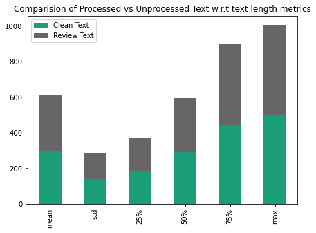

```python
f, ax = plt.subplots(figsize=(7,5))
a = dft['Clean Text'].apply(lambda x: len(x)).describe().drop(['count','min'])
b = dft['Review Text'].apply(lambda x: len(x)).describe().drop(['count','min'])
temp = pd.DataFrame({'Clean Text':a, 'Review Text':b})
temp.plot.bar(stacked=True, colormap='Dark2', ax=ax);
ax.set_title("Comparision of Processed vs Unprocessed Text w.r.t text length metrics")
```

```python
from nltk.corpus import stopwords
stop_words = set(stopwords.words('english'))

tokens = []
for row in dft['Clean Text']:
    for tk in row.split():
        if tk not in stop_words and (tk != ''):
            tokens.append(tk)
```

```python
len(tokens)
```

```
667515
```

```python
dft['Clean Tokens'] = dft['Clean Text']\
.apply(lambda x: [w for w in nltk.tokenize.word_tokenize(x) if w not in stop_words and (w != '')])
```

```python
dft['Clean Tokens'].apply(lambda x: len(x)).sum()
```

```
667350
```

```python
aa = [w for z in dft['Clean Tokens'] for w in z]
aaa = set(aa)
bbb = set(tokens)
len(set(aa)) - len(set(tokens))
asda = [w for w in bbb if w not in aaa]
```

```python
a12 = " ".join(['gonna', 'gotta', 'wanna', 'cannot'])
nltk.tokenize.word_tokenize(a12)
```

```
['gon', 'na', 'got', 'ta', 'wan', 'na', 'can', 'not']
```

Difference in token length through nltk and manually. It appears that manual "tokens" are more in number when compared to nltk generated tokens. After comparing the two above it's seen that nltk word tokenizer does not process the words "gonna, gotta, cannot, wanna, cannot" etc correctly and breaks each into two tokens. This however should lead to more token with nltk, opposite to what we are seeing here. Basically when token is split it generates more stop words like "not", "can", "Can" etc. which are removed hence resulting in fewer tokens.

##### Lemmatize

```python
pos_tag(['being'])
```

```
[('being', 'VBG')]
```

```python
def Lemma(tokens):
    lemma = WordNetLemmatizer()
    lemma_sent = []

    for word, tag in pos_tag(tokens):
        if tag.startswith('NN'):
            pos= 'n'
        elif tag.startswith('VB'):
            pos= 'v'
        else:
            pos = 'a'
        lemma_sent.append(lemma.lemmatize(word, pos))

    return lemma_sent
```

```python
tokens_ = Lemma(tokens)
```

```python
freq = nltk.FreqDist(tokens_)
items = sorted(freq.items(), key= lambda kv: kv[1], reverse= True)
```

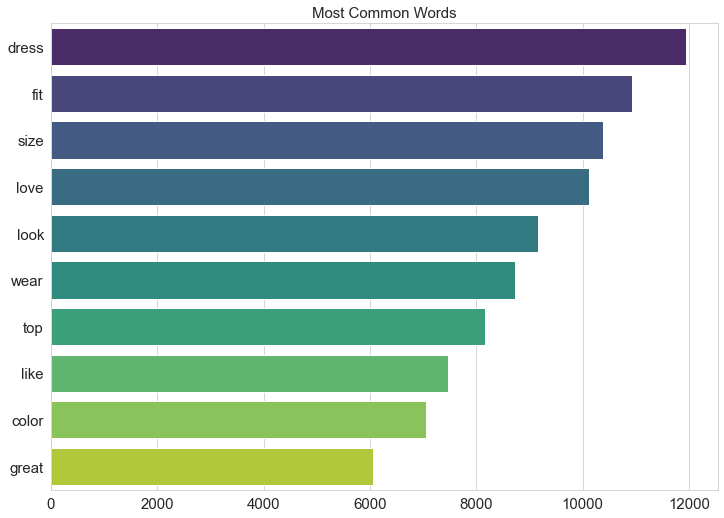

```python
k,v = zip(*items)

fig, ax = plt.subplots(figsize=(10,7))
sns.set_style('whitegrid')

sns.barplot(x=list(v[:10]), y=list(k[:10]), palette ='viridis')
plt.tight_layout()
plt.title('Most Common Words', size=15)
plt.tick_params(labelsize=15)
```

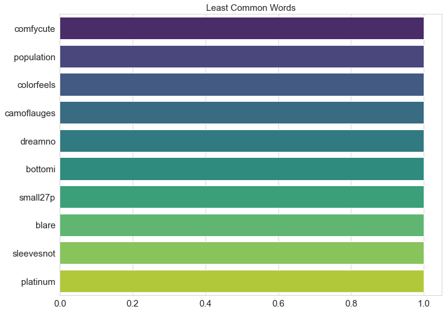

```python
fig, ax = plt.subplots(figsize=(10,7))
sns.set_style('whitegrid')

sns.barplot(x=list(v[-10:]), y=list(k[-10:]), palette ='viridis')
plt.tight_layout()
plt.title('Least Common Words', size=15)
plt.tick_params(labelsize=15)
plt.show()
```

```python
Department_Name = list(dft['Department Name'].unique())
token_labels = []
for i, dep in enumerate(Department_Name):
    token_labels.append([])
    for row in dft[dft['Department Name'] == dep]['Clean Text']:
        for tk in row.split():
            if tk not in stop_words and (tk != ''):
                token_labels[i].append(tk)

# Lemmatize tokens
token_labels_lem = []
for i in range(len(Department_Name)):
    token_labels_lem.append(Lemma(token_labels[i]))
```

```python
freq_label = []
item_label = []
for i in range(len(Department_Name)):

    freq_label.append(nltk.FreqDist(token_labels_lem[i]))
    item_label.append(sorted(freq_label[i].items(), key= lambda kv: kv[1], reverse = True))
```

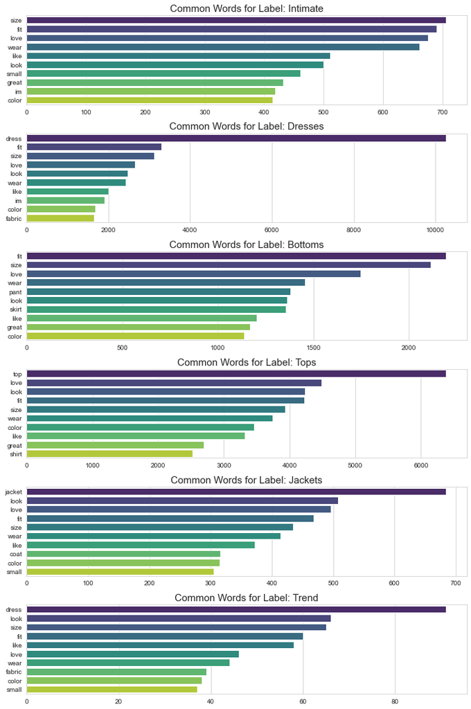

```python
fig, axs = plt.subplots(6, figsize=(10,15))

for i in range(len(Department_Name)):

    k1,v1= zip(*item_label[i])
    sns.barplot(y =list(k1[:10]),x= list(v1[:10]), palette='viridis',ax=axs[i])
    plt.tight_layout()
    axs[i].set_title('Common Words for Label: {}'.format(Department_Name[i]), size=15)
```

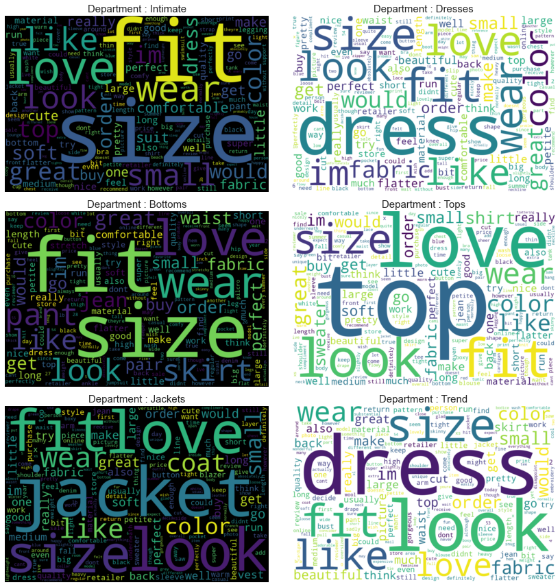

```python
from wordcloud import WordCloud

def wordcloud(freqd,c):
    if c%2 == 0:
        color = 'Black'
    else:
        color = 'white'
    wc = WordCloud(width=1200, height=800,
                  background_color=color,
                  max_words=200)
    wc = wc.generate_from_frequencies(freqd)
    return wc
    #fig=plt.figure(figsize=(6,4))

fig = plt.figure(figsize=(12,12))

wc1 = [None] *6
for i in range(len(Department_Name)):
    axs = fig.add_subplot(3,2,i+1)
    wc1[i] = wordcloud(dict(item_label[i]),i)
    axs.imshow(wc1[i], interpolation='bilinear')
    axs.axis('off')
    axs.set_title("Department : {}".format(Department_Name[i]), size=15)

plt.tight_layout()
plt.show()
```

```python
dft[dft['Department Name'] == "Intimate"]['Clean Text']
```

```
0                                                                                                                                                                                                                                                                                                           …
13                                                                                             bought the black xs to go under the larkspur midi dress because they didnt bother lining the skirt portion grrrrrrrrrrrmy stats are 34a282936 and the xs fit very smoothly around the chest and was flowy aro…
25                                                                                                                       loved the material but i didnt really look at how long the dress was before i purchased both a large and a medium im 55 and there was atleast 5 of material at my feet the gaps in …
28                                                                                                                                                                                                                                                                            i have several of goodhyouman …
34                                                                                                                                                                                               this is such a neat dress the color is great and the fabric is super soft i am tall so the long length was …
                                                                                                                                                                                                                                    ...
23463                                                                                           these pants overall are very comfortable but have an unusual fit they tend to run a bit short and i always have to get pants hemmed shorter so if you have long legs or like more draping you probably wont …
23468    i love this little chemise the adjustable straps sold me because im petite i generally wear a small27p im about 51 124 lbs i purchased a small and it fit perfect the fabric is nice not too thin or too thick i would totally wear it just as easily as a nightgown or beach coverup ive never bee…
23469                                                                                                                                                       my size was not available so based on reviews stating the bagginess of a certain area i sized down and glad i did i never size down because i do…
23471                                                                                                                                                                                                                                                                                                       …
23476                                                                                                                                                                                                                                                                                                       …
Name: Clean Text, Length: 1653, dtype: object
```

```python
dft.dtypes
```

```
Clothing ID                 int64
Age                         int64
Title                      object
Review Text                object
Rating                      int64
Recommended IND             int64
Positive Feedback Count     int64
Division Name              object
Department Name            object
Class Name                 object
Clean Text                 object
Clean Tokens               object
dtype: object
```